# MonteCarlo 08

8 actividades; plazo del cliente 34; percentiles y retraso esperado

# Enunciado

Considere el proyecto cuyo cuadro de prelaciones y estimaciones optimista, más probable y pesimista (en semanas) se adjunta; las duraciones siguen distribuciones triangulares independientes. El cliente ha fijado la entrega en la semana 34 con una penalización por cada semana de retraso.

1. Calcule la duración del proyecto con las duraciones medias de las triangulares, $(a + m + b)/3$, y el camino crítico.

2. Simule 20000 réplicas con la matriz de caminos y obtenga los percentiles 10, 50, 80, 90 y 95 de la duración. ¿Qué significa cada uno para el jefe de proyecto?

3. ¿Qué probabilidad hay de pagar penalización? ¿Cuántas semanas de retraso se superan sólo con probabilidad 0,05? Calcule el retraso medio esperado (media de máx(0, T − plazo)).

4. ¿Qué fecha habría que haber comprometido para que la probabilidad de penalización fuera del 10 %? Compare con la duración media: ¿cuántas semanas de *margen* supone?

Tabla 1: Cuadro de datos del enunciado

| activity | predecessor | a | m | b |
| --- | --- | --- | --- | --- |
| A | --- | 5 | 6 | 10 |
| B | --- | 6 | 9 | 9 |
| C | A,B | 3 | 6 | 9 |
| D | B | 2 | 2 | 5 |
| E | C | 3 | 4 | 8 |
| F | C | 2 | 5 | 5 |
| G | E,F | 1 | 4 | 7 |
| H | D,G | 6 | 8 | 10 |

# Resolución

## Apartado 1

1. Calcule la duración del proyecto con las duraciones medias de las triangulares, $(a + m + b)/3$, y el camino crítico.

Tabla 2: Media de cada triangular

| activity | A | B | C | D | E | F | G | H |
| --- | --- | --- | --- | --- | --- | --- | --- | --- |
| (a + m + b)/3 | (5 + 6 + 10)/3 = 7.00 | (6 + 9 + 9)/3 = 8.00 | (3 + 6 + 9)/3 = 6.00 | (2 + 2 + 5)/3 = 3.00 | (3 + 4 + 8)/3 = 5.00 | (2 + 5 + 5)/3 = 4.00 | (1 + 4 + 7)/3 = 4.00 | (6 + 8 + 10)/3 = 8.00 |

Cálculo de los tiempos tempranos y tardíos de los sucesos y de las holguras totales paso a paso. El primer paso muestra el grafo resuelto; a partir del siguiente se calcula desde el principio (avance con los botones):

[figure not shown]

paso 0 de 28

[figure not shown]

Figura 1: Grafo PERT con las duraciones medias

Tabla 3: Duración media de cada ruta

|  | actividades | duración media = suma | duración media |
| --- | --- | --- | --- |
| Route_1 | A – C – E – G – H | A(7.00) + C(6.00) + E(5.00) + G(4.00) + H(8.00) = 30.00 | 30 |
| Route_2 | A – C – F – G – H | A(7.00) + C(6.00) + F(4.00) + G(4.00) + H(8.00) = 29.00 | 29 |
| Route_3 | B – C – E – G – H | B(8.00) + C(6.00) + E(5.00) + G(4.00) + H(8.00) = 31.00 | 31 |
| Route_4 | B – C – F – G – H | B(8.00) + C(6.00) + F(4.00) + G(4.00) + H(8.00) = 30.00 | 30 |
| Route_5 | B – D – H | B(8.00) + D(3.00) + H(8.00) = 19.00 | 19 |

**Respuesta:** con las medias de las triangulares la duración del proyecto es 31.00 semanas y el camino crítico B – C – E – G – H.

## Apartado 2

2. Simule 20000 réplicas con la matriz de caminos y obtenga los percentiles 10, 50, 80, 90 y 95 de la duración. ¿Qué significa cada uno para el jefe de proyecto?

En cada réplica se sortea la duración de cada actividad con su triangular, se suman las duraciones a lo largo de cada ruta y la duración del proyecto es la de la ruta más larga. El percentil $p$ de las réplicas es el valor que deja por debajo la proporción $p$ de ellas: se ordenan de menor a mayor y se toma la que ocupa la posición $p\cdot N$ (interpolando).

|  | P10 | P50 | P80 | P90 | P95 |
| --- | --- | --- | --- | --- | --- |
| posición en la muestra ordenada | ≈ 2000 de 20000 | ≈ 10000 de 20000 | ≈ 16000 de 20000 | ≈ 18000 de 20000 | ≈ 19000 de 20000 |
| duración (semanas) | 28.45 | 31.32 | 33.23 | 34.22 | 35.03 |

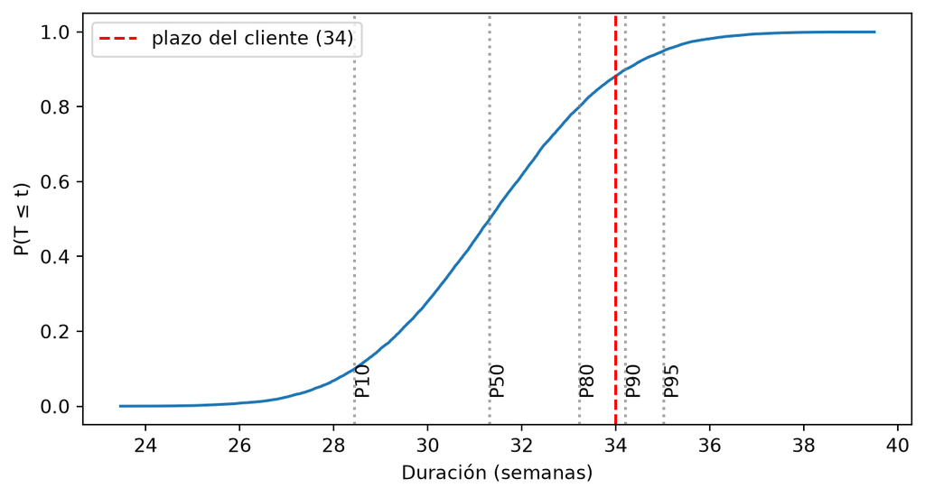

Figura 2: Función de distribución simulada de la duración

**Respuesta:** P10 = 28.45, P50 = 31.32, P80 = 33.23, P90 = 34.22 y P95 = 35.03 semanas. Para el jefe de proyecto, P10 es una fecha optimista (sólo 1 de cada 10 réplicas termina antes); P50, la mediana (tan probable acabar antes como después); P80, una fecha que se cumple cuatro de cada cinco veces; P90 y P95, fechas «seguras» que sólo se superan el 10 % y el 5 % de las veces. La diferencia P95 − P50 = 3.71 semanas es el margen que hay que añadir a una previsión central para hacerla fiable.

## Apartado 3

3. ¿Qué probabilidad hay de pagar penalización? ¿Cuántas semanas de retraso se superan sólo con probabilidad 0,05? Calcule el retraso medio esperado (media de máx(0, T − plazo)).

Se paga penalización en las réplicas que superan el plazo del cliente; el retraso de cada réplica es $\max(0, T - \text{plazo})$ y se estudia como cualquier otra variable simulada.

P(T > 34) ≈ 2367/20000 = 0.1183: se paga penalización en el 11.8 % de las réplicas. El percentil 95 del retraso es 1.03 semanas (= P95 − plazo = 35.03 − 34). El retraso medio es la media de las 20000 réplicas de máx(0, T − 34) (las que terminan a tiempo cuentan 0): 2551.8/20000 = 0.128 semanas.

**Respuesta:** probabilidad de pagar penalización 0.1183; el retraso supera 1.03 semanas sólo con probabilidad 0,05; retraso medio esperado 0.128 semanas (multiplicado por la penalización semanal da el coste esperado de la cláusula).

## Apartado 4

4. ¿Qué fecha habría que haber comprometido para que la probabilidad de penalización fuera del 10 %? Compare con la duración media: ¿cuántas semanas de *margen* supone?

Para que P(T > fecha) = 0,10 hay que comprometer el percentil 90 de las réplicas: 34.22 semanas, es decir, semana 35 en semanas enteras (P(T > 35) ≈ 0.052). Comprometer la media (31.00) supondría penalización en el 55.7% de los casos, algo más de la mitad por el sesgo de fusión de las rutas.

**Respuesta:** habría que haber comprometido 34.22 semanas (semana 35), con un margen de 34.22 − 31.00 = 3.22 semanas sobre la duración media.